# Moral Machine (Trolley Problem) - Re-Analysis

Scott Claessens

2020-03-05

# 1. Introduction

The purpose of this document is to re-analyse the data for Awad et al. (2020) published in PNAS. We thank the authors for making their data publicly available for re-analysis.

In the paper, the authors run country-level regressions showing that relational mobility (a country-level variable measuring “the fluidity with which people can develop new relationships”) predicts the probability of acting in three variations of the trolley problem. They conduct this key analysis in the following way:

```r
library(tidyverse)
library(countrycode)

# load the country-level dataset
load("osf_mxa6z/countrylevelregressions.rdata")

# trim the country-level dataset
dd <-
  ddl %>%
  mutate(Continent =
           countrycode(sourcevar = two_letter_code,
                       origin = "iso2c",
                       destination = "continent"),
         Continent = factor(
           Continent, levels = c("Europe", "Americas",
                                 "Asia", "Oceania"))) %>%
  filter(!is.na(Continent))

# run regression without controls (Switch only, for an example)
fit <- lm(Switch ~ RML, data = dd)
summary(fit)
```

```
##
## Call:
## lm(formula = Switch ~ RML, data = dd)
##
## Residuals:
##       Min        1Q    Median        3Q       Max
## -0.068836 -0.015375 -0.002689  0.013033  0.103796
##
## Coefficients:
##             Estimate Std. Error t value Pr(>|t|)
## (Intercept) 0.803883   0.007849 102.421  < 2e-16 ***
## RML         0.157996   0.037860   4.173 0.000429 ***
## ---
## Signif. codes:  0 '***' 0.001 '**' 0.01 '*' 0.05 '.' 0.1 ' ' 1
##
## Residual standard error: 0.0373 on 21 degrees of freedom
##   (137 observations deleted due to missingness)
## Multiple R-squared:  0.4533, Adjusted R-squared:  0.4273
## F-statistic: 17.42 on 1 and 21 DF,  p-value: 0.0004295
```

Indeed, we find a positive association between relational mobility in a country `RML` and the proportion of individuals in that country choosing to act in the Switch version of the trolley problem.

However, this analysis has some methodological flaws:

1. It uses a reduced country-level dataset (only 23 countries are analysed) as opposed to leveraging the statistical power of the full individual-level dataset using multi-level regression.
2. It treats the outcome variable as Gaussian, when in fact it is a country-level proportion.
3. It does not account for the non-independence of countries that arise due to shared cultural ancestry and geographic proximity (Galton’s problem).
4. It does not account for measurement error on the relational mobility variable, which is actually an estimated latent variable from a confirmatory factor analysis and so has standard errors. I found these standard errors from [this model output on OSF](https://osf.io/e679h/).

We would like to see if the analysis reported by the authors is robust to these violations. To do this, we conduct Bayesian multi-level logistic regression in R using the [brms package](https://github.com/paul-buerkner/brms) (Bürkner 2017).

# 2. Load data

## 2.1. Trolley data

First, load the individual-level data.

```r
d <- read.csv("osf_mxa6z/Shared_data_allResponses.csv", na.strings = NULL)
```

Add country-level data on relational mobility from Thomson et al. (2018) (see [here](https://osf.io/qfbjc/) and [here](http://relationalmobility.org/) for more information about these values) and filter to only include countries with relational mobility data.

```r
d <- d %>% inner_join(read.csv("data/rm.csv"), by = "country_code")
```

This dataset contains information on 182780 decisions from 56871 individuals across 38 countries. Interestingly, we have data for more countries than the analysis above, which only included 23 countries. Our dataset has information for Egypt, South Korea, Libya, etc. which were not included in the published analyses, presumably because they were beneath the “lower bound of 200 responses per scenario and country” (Awad et al. 2020, 1). The advantage of using multi-level modelling is that arbitrary cutoffs like this are not necessary: countries with smaller sample sizes will be estimated with more uncertainty and be pulled more towards the grand mean via pooling (see McElreath (2016) for more information).

## 2.2. Distance matrices

Load covariance matrices for geographic and linguistic distance between countries.

```r
load("data/A_geo.rda")
load("data/A_ling.rda")
```

These covariance matrices are created for the 38 countries in the full dataset, based on geographic and linguistic distance between countries. We do not directly code the creation of the distance matrices in this Markdown document, but briefly outline the methods used to create them here:

Geographic distance between two countries was calculated as the geodesic distance between country capital cities, using the R packages [maps](https://cran.r-project.org/web/packages/maps/index.html) (Brownrigg 2018) and [geosphere](https://cran.r-project.org/web/packages/geosphere/index.html) (Hijmans 2017).

Linguistic distance between two countries was calculated as the cultural proximity between all languages spoken within those countries, weighted by speaker percentages. We acquired cultural proximity data by combining the language family trees provided by [Glottolog v3.0](https://glottolog.org/) (Hammarstrom, Forkel, and Haspelmath 2018) into one global language tree (undated and unresolved), and then calculated cultural proximity $s$ between two languages $j$ and $k$ as the distance (in number of nodes traversed) of their most recent common ancestor $i$ to the root of the tree, through the following formula:

$$s_{jk} = \frac{n_r-n_i}{n_r}$$

where $n_r$ is the maximum path length (in number of nodes traversed) leading to the pan-human root and $n_i$ is the maximum path length leading to node. We then combined these proximities with speaker data from [Ethnologue 21](https://www.ethnologue.com/ethnoblog/gary-simons/welcome-21st-edition) (Eberhard, Simons, and Fennig 2018) and compared every language spoken within those countries by at least 1 permille of the population, weighted by speaker percentages, through the following formula:

$$w_{lm} = \Sigma \Sigma p_{lj} p_{mk} s_{jk}$$

where $p_{lj}$ is the percentage of the population in nation $l$ speaking language $j$, $p_{mk}$ is the percentage of the population in nation $m$ speaking language $k$, and $s_{jk}$ is the proximity measure between languages $j$ and $k$ (Eff 2008).

# 3. Fit Bayesian multi-level logistic regressions

We will use brms to fit the models.

```r
library(brms)
```

We use `Outcome` as the binary response variable, and predict the probability of the outcome (sacrificing in the trolley problem) with (1) the scenario type `Scenario`, (2) country-level relational mobility `RML`, and (3) the interaction between these. We also include random intercepts for `UserID`, and allow further random intercepts for `country_code` and `country_code2` (an identical variable) to covary according to our linguistic and geographic covariance matrices.

```r
# country_code as factor
d$country_code <- factor(d$country_code)

# identical variable for covariance matrices
d$country_code2 <- d$country_code
```

Before this, we run a simple model without any interaction with `RML`.

```r
m1 <- brm(Outcome ~ 0 + intercept + Scenario +
            (0 + intercept | country_code) +
            (0 + intercept | country_code2) +
            (0 + intercept | UserID),
          cov_ranef = list(country_code  = A_ling,
                           country_code2 = A_geo),
          data = d, family = bernoulli,
          prior = c(prior(normal(0, 0.5), class = b),
                    prior(student_t(3, 0, 1), class = sd)),
          iter = 4000, warmup = 2000, cores = 4, chains = 4,
          control = list(adapt_delta = 0.99, max_treedepth = 15),
          seed = 2113)

save(m1, file = "models/m1.rda")
```

We then add the interaction with `RML` (without measurement error).

```r
m2 <- brm(Outcome ~ 0 + intercept + Scenario*RML +
            (0 + intercept | country_code) +
            (0 + intercept | country_code2) +
            (0 + intercept | UserID),
          cov_ranef = list(country_code  = A_ling,
                           country_code2 = A_geo),
          data = d, family = bernoulli,
          prior = c(prior(normal(0, 0.5), class = b),
                    prior(student_t(3, 0, 1), class = sd)),
          iter = 4000, warmup = 2000, cores = 4, chains = 4,
          control = list(adapt_delta = 0.99, max_treedepth = 15),
          inits = 0, seed = 2113)

save(m2, file = "models/m2.rda")
```

We then add measurement error to `RML`. Initially, we used the same priors as the previous model for `m3`, but it consistently resulted in a multimodal posterior, which is difficult to interpret. In an attempt to avoid this, we set the priors based on the posterior distribution from `m2`, a technique known as posterior passing. Because there is so much data (182780 data points), these priors will be overwhelmed by the data anyway - they are just to get the model sampling on track.

```r
m3 <- brm(Outcome ~ 0 + intercept + Scenario*me(x = RML, sdx = RML_SE, gr = country_code) +
           (0 + intercept | country_code) +
           (0 + intercept | country_code2) +
           (0 + intercept | UserID),
          cov_ranef = list(country_code  = A_ling,
                           country_code2 = A_geo),
          data = d, family = bernoulli,
          # use approximated priors from m2 posterior to help model converge
          prior = c(prior(normal(0.10,  0.13), class = b, coef = "intercept"),
                    prior(normal(1.22,  0.02), class = b, coef = "ScenarioLoop"),
                    prior(normal(1.89,  0.02), class = b, coef = "ScenarioSwitch"),
                    prior(normal(0.73,  0.27), class = b,
                          coef = "mexEQRMLsdxEQRML_SEgrEQcountry_code"),
                    prior(normal(-0.31, 0.11), class = b,
                          coef = "mexEQRMLsdxEQRML_SEgrEQcountry_code:ScenarioLoop"),
                    prior(normal(-0.06, 0.11), class = b,
                          coef = "mexEQRMLsdxEQRML_SEgrEQcountry_code:ScenarioSwitch"),
                    prior(student_t(3, 0.25, 0.08), class = sd,
                          coef = "intercept", group = "country_code"),
                    prior(student_t(3, 0.12, 0.08), class = sd,
                          coef = "intercept", group = "country_code2"),
                    prior(normal(1.62, 0.01), class = sd,
                          coef = "intercept", group = "UserID")),
          iter = 4000, warmup = 2000, cores = 4, chains = 4,
          control = list(adapt_delta = 0.99, max_treedepth = 15),
          save_mevars = TRUE, seed = 2113)

save(m3, file = "models/m3.rda")
```

We also add GDP, individualism, and religiosity as control variables. We use listwise deletion as a default, following the original paper.

```r
controls <- dd %>% select(two_letter_code, GDP_log10, Individualism, Religion_is_very_important)
d <- d %>% left_join(controls, by = c("country_code" = "two_letter_code"))
rm(controls)

# centre predictors
d$GDP_log10 <- d$GDP_log10 - mean(d$GDP_log10, na.rm=T)
d$Individualism <- d$Individualism - mean(d$Individualism, na.rm=T)
d$Religion_is_very_important <- d$Religion_is_very_important - mean(d$Religion_is_very_important, na.rm=T)
```

```r
# control for GDP
m4 <- brm(Outcome ~ 0 + intercept + Scenario*me(x = RML, sdx = RML_SE, gr = country_code) +
            Scenario:GDP_log10 +
            (0 + intercept | country_code) +
            (0 + intercept | country_code2) +
            (0 + intercept | UserID),
          cov_ranef = list(country_code  = A_ling,
                           country_code2 = A_geo),
          data = d, family = bernoulli,
          # use approximated priors from m2 posterior to help model converge
          prior = c(prior(normal(0.10,  0.13), class = b, coef = "intercept"),
                    prior(normal(1.22,  0.02), class = b, coef = "ScenarioLoop"),
                    prior(normal(1.89,  0.02), class = b, coef = "ScenarioSwitch"),
                    prior(normal(0.73,  0.27), class = b,
                          coef = "mexEQRMLsdxEQRML_SEgrEQcountry_code"),
                    prior(normal(-0.31, 0.11), class = b,
                          coef = "mexEQRMLsdxEQRML_SEgrEQcountry_code:ScenarioLoop"),
                    prior(normal(-0.06, 0.11), class = b,
                          coef = "mexEQRMLsdxEQRML_SEgrEQcountry_code:ScenarioSwitch"),
                    prior(student_t(3, 0.25, 0.08), class = sd,
                          coef = "intercept", group = "country_code"),
                    prior(student_t(3, 0.12, 0.08), class = sd,
                          coef = "intercept", group = "country_code2"),
                    prior(normal(1.62, 0.01), class = sd,
                          coef = "intercept", group = "UserID"),
                    # add new priors for control
                    prior(normal(0, 0.5), class = b, coef = "ScenarioSwitch:GDP_log10"),
                    prior(normal(0, 0.5), class = b, coef = "ScenarioLoop:GDP_log10"),
                    prior(normal(0, 0.5), class = b, coef = "ScenarioFootbridge:GDP_log10")),
          iter = 4000, warmup = 2000, cores = 4, chains = 4,
          control = list(adapt_delta = 0.99, max_treedepth = 15),
          save_mevars = TRUE, seed = 2113)

save(m4, file = "models/m4.rda")
```

```r
# control for Individualism
m5 <- brm(Outcome ~ 0 + intercept + Scenario*me(x = RML, sdx = RML_SE, gr = country_code) +
            Scenario:Individualism +
            (0 + intercept | country_code) +
            (0 + intercept | country_code2) +
            (0 + intercept | UserID),
          cov_ranef = list(country_code  = A_ling,
                           country_code2 = A_geo),
          data = d, family = bernoulli,
          # use approximated priors from m2 posterior to help model converge
          prior = c(prior(normal(0.10,  0.13), class = b, coef = "intercept"),
                    prior(normal(1.22,  0.02), class = b, coef = "ScenarioLoop"),
                    prior(normal(1.89,  0.02), class = b, coef = "ScenarioSwitch"),
                    prior(normal(0.73,  0.27), class = b,
                          coef = "mexEQRMLsdxEQRML_SEgrEQcountry_code"),
                    prior(normal(-0.31, 0.11), class = b,
                          coef = "mexEQRMLsdxEQRML_SEgrEQcountry_code:ScenarioLoop"),
                    prior(normal(-0.06, 0.11), class = b,
                          coef = "mexEQRMLsdxEQRML_SEgrEQcountry_code:ScenarioSwitch"),
                    prior(student_t(3, 0.25, 0.08), class = sd,
                          coef = "intercept", group = "country_code"),
                    prior(student_t(3, 0.12, 0.08), class = sd,
                          coef = "intercept", group = "country_code2"),
                    prior(normal(1.62, 0.01), class = sd,
                          coef = "intercept", group = "UserID"),
                    # add new priors for control
                    prior(normal(0, 0.5), class = b, coef = "ScenarioSwitch:Individualism"),
                    prior(normal(0, 0.5), class = b, coef = "ScenarioLoop:Individualism"),
                    prior(normal(0, 0.5), class = b, coef = "ScenarioFootbridge:Individualism")),
          iter = 4000, warmup = 2000, cores = 4, chains = 4,
          control = list(adapt_delta = 0.99, max_treedepth = 15),
          save_mevars = TRUE, seed = 2113)

save(m5, file = "models/m5.rda")
```

```r
# control for religiosity
m6 <- brm(Outcome ~ 0 + intercept + Scenario*me(x = RML, sdx = RML_SE, gr = country_code) +
            Scenario:Religion_is_very_important +
            (0 + intercept | country_code) +
            (0 + intercept | country_code2) +
            (0 + intercept | UserID),
          cov_ranef = list(country_code  = A_ling,
                           country_code2 = A_geo),
          data = d, family = bernoulli,
          # use approximated priors from m2 posterior to help model converge
          prior = c(prior(normal(0.10,  0.13), class = b, coef = "intercept"),
                    prior(normal(1.22,  0.02), class = b, coef = "ScenarioLoop"),
                    prior(normal(1.89,  0.02), class = b, coef = "ScenarioSwitch"),
                    prior(normal(0.73,  0.27), class = b,
                          coef = "mexEQRMLsdxEQRML_SEgrEQcountry_code"),
                    prior(normal(-0.31, 0.11), class = b,
                          coef = "mexEQRMLsdxEQRML_SEgrEQcountry_code:ScenarioLoop"),
                    prior(normal(-0.06, 0.11), class = b,
                          coef = "mexEQRMLsdxEQRML_SEgrEQcountry_code:ScenarioSwitch"),
                    prior(student_t(3, 0.25, 0.08), class = sd,
                          coef = "intercept", group = "country_code"),
                    prior(student_t(3, 0.12, 0.08), class = sd,
                          coef = "intercept", group = "country_code2"),
                    prior(normal(1.62, 0.01), class = sd,
                          coef = "intercept", group = "UserID"),
                    # add new priors for control
                    prior(normal(0, 0.5), class = b,
                          coef = "ScenarioSwitch:Religion_is_very_important"),
                    prior(normal(0, 0.5), class = b,
                          coef = "ScenarioLoop:Religion_is_very_important"),
                    prior(normal(0, 0.5), class = b,
                          coef = "ScenarioFootbridge:Religion_is_very_important")),
          iter = 4000, warmup = 2000, cores = 4, chains = 4,
          control = list(adapt_delta = 0.99, max_treedepth = 15),
          save_mevars = TRUE, seed = 2113)

save(m6, file = "models/m6.rda")
```

Finally, fit models with just Asian countries.

```r
d_Asia <-
  d %>%
  mutate(
    Continent =
      countrycode(sourcevar = country_code,
                  origin = "iso2c", destination = "continent"),
    Continent =
      factor(Continent, levels = c("Europe", "Americas",
                                   "Asia", "Oceania", "Africa"))) %>%
  filter(Continent == "Asia")
```

```r
m7 <- brm(Outcome ~ 0 + intercept + Scenario*RML +
            (0 + intercept | country_code) +
            (0 + intercept | country_code2) +
            (0 + intercept | UserID),
          cov_ranef = list(country_code  = A_ling,
                           country_code2 = A_geo),
          data = d_Asia, family = bernoulli,
          prior = c(prior(normal(0, 0.5), class = b),
                    prior(student_t(3, 0, 1), class = sd)),
          iter = 4000, warmup = 2000, cores = 4, chains = 4,
          control = list(adapt_delta = 0.99, max_treedepth = 15),
          save_mevars = TRUE, seed = 2113)

save(m7, file = "models/m7.rda")
```

```r
m8 <- brm(Outcome ~ 0 + intercept + Scenario*me(x = RML, sdx = RML_SE, gr = country_code) +
            (0 + intercept | country_code) +
            (0 + intercept | country_code2) +
            (0 + intercept | UserID),
          cov_ranef = list(country_code  = A_ling,
                           country_code2 = A_geo),
          data = d_Asia, family = bernoulli,
          # use approximated priors from m7 to help the model converge
          prior = c(prior(normal(0.05,  0.26), class = b, coef = "intercept"),
                    prior(normal(1.01,  0.07), class = b, coef = "ScenarioLoop"),
                    prior(normal(1.85,  0.08), class = b, coef = "ScenarioSwitch"),
                    prior(normal(0.42,  0.47), class = b,
                          coef = "mexEQRMLsdxEQRML_SEgrEQcountry_code"),
                    prior(normal(-0.99, 0.27), class = b,
                          coef = "mexEQRMLsdxEQRML_SEgrEQcountry_code:ScenarioLoop"),
                    prior(normal(-0.31, 0.29), class = b,
                          coef = "mexEQRMLsdxEQRML_SEgrEQcountry_code:ScenarioSwitch"),
                    prior(student_t(3, 0.36, 0.22), class = sd,
                          coef = "intercept", group = "country_code"),
                    prior(student_t(3, 0.38, 0.21), class = sd,
                          coef = "intercept", group = "country_code2"),
                    prior(normal(1.82, 0.05), class = sd,
                          coef = "intercept", group = "UserID")),
          iter = 4000, warmup = 2000, cores = 4, chains = 4,
          control = list(adapt_delta = 0.99, max_treedepth = 15),
          inits = 0, seed = 2113)

save(m8, file = "models/m8.rda")
```

# 4. Results

## 4.1. Controlling for non-independence (intercept-only)

```r
summary(m1)
```

```
##  Family: bernoulli
##   Links: mu = logit
## Formula: Outcome ~ 0 + intercept + Scenario + (0 + intercept | country_code) + (0 + intercept | country_code2) + (0 + intercept | UserID)
##    Data: d (Number of observations: 182780)
## Samples: 4 chains, each with iter = 4000; warmup = 2000; thin = 1;
##          total post-warmup samples = 8000
##
## Group-Level Effects:
## ~country_code (Number of levels: 38)
##               Estimate Est.Error l-95% CI u-95% CI Rhat Bulk_ESS Tail_ESS
## sd(intercept)     0.32      0.06     0.19     0.44 1.00     1985     1362
##
## ~country_code2 (Number of levels: 38)
##               Estimate Est.Error l-95% CI u-95% CI Rhat Bulk_ESS Tail_ESS
## sd(intercept)     0.09      0.07     0.00     0.27 1.01      769     1019
##
## ~UserID (Number of levels: 56871)
##               Estimate Est.Error l-95% CI u-95% CI Rhat Bulk_ESS Tail_ESS
## sd(intercept)     1.62      0.01     1.59     1.65 1.00     2975     4547
##
## Population-Level Effects:
##                Estimate Est.Error l-95% CI u-95% CI Rhat Bulk_ESS Tail_ESS
## intercept          0.08      0.15    -0.22     0.37 1.00     2739     3613
## ScenarioLoop       1.19      0.02     1.16     1.22 1.00     9324     6825
## ScenarioSwitch     1.88      0.02     1.84     1.91 1.00     8232     6301
##
## Samples were drawn using sampling(NUTS). For each parameter, Eff.Sample
## is a crude measure of effective sample size, and Rhat is the potential
## scale reduction factor on split chains (at convergence, Rhat = 1).
```

Plot the predictions of `m1`.

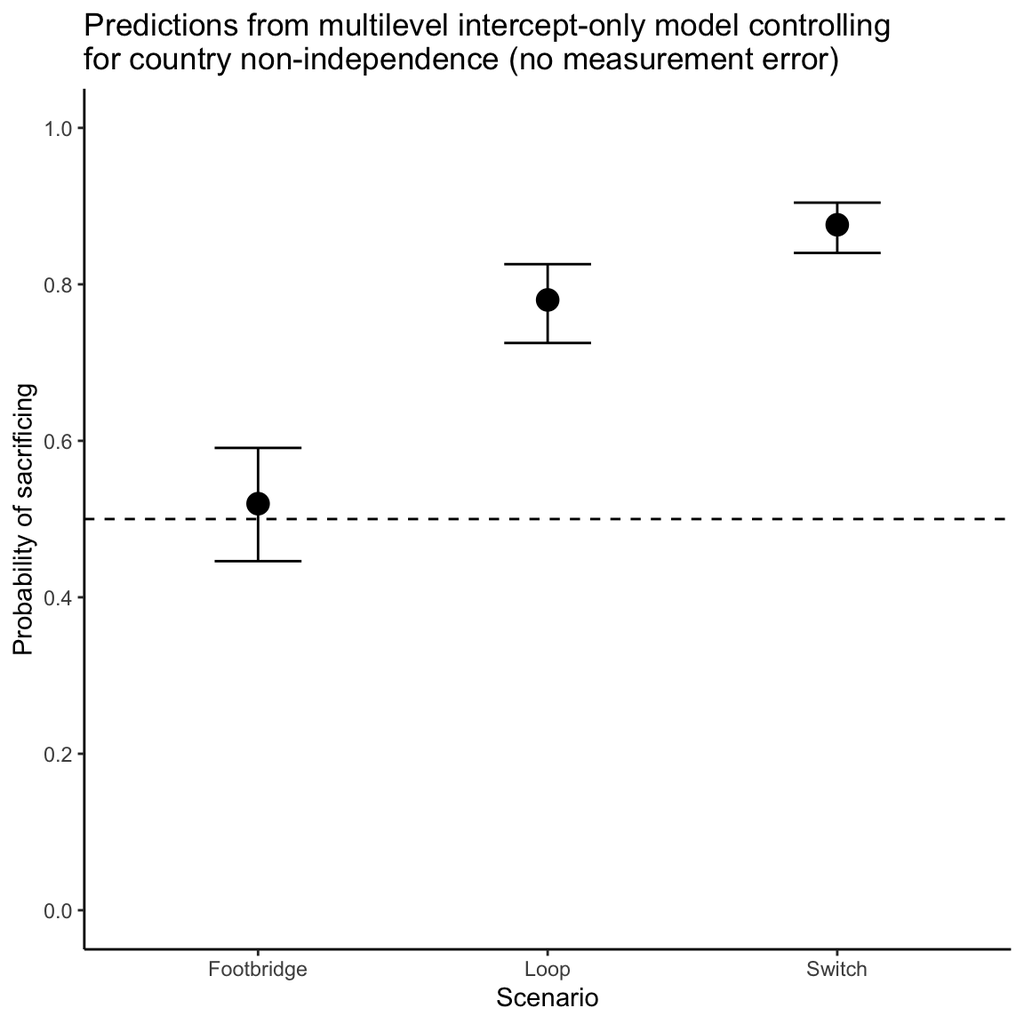

## 4.2. Controlling for non-independence without measurement error on RML

```r
summary(m2)
```

```
##  Family: bernoulli
##   Links: mu = logit
## Formula: Outcome ~ 0 + intercept + Scenario * RML + (0 + intercept | country_code) + (0 + intercept | country_code2) + (0 + intercept | UserID)
##    Data: d (Number of observations: 182780)
## Samples: 4 chains, each with iter = 4000; warmup = 2000; thin = 1;
##          total post-warmup samples = 8000
##
## Group-Level Effects:
## ~country_code (Number of levels: 38)
##               Estimate Est.Error l-95% CI u-95% CI Rhat Bulk_ESS Tail_ESS
## sd(intercept)     0.25      0.08     0.05     0.39 1.00     1116     1106
##
## ~country_code2 (Number of levels: 38)
##               Estimate Est.Error l-95% CI u-95% CI Rhat Bulk_ESS Tail_ESS
## sd(intercept)     0.12      0.08     0.00     0.30 1.01      851     1843
##
## ~UserID (Number of levels: 56871)
##               Estimate Est.Error l-95% CI u-95% CI Rhat Bulk_ESS Tail_ESS
## sd(intercept)     1.62      0.01     1.59     1.65 1.00     2892     4966
##
## Population-Level Effects:
##                    Estimate Est.Error l-95% CI u-95% CI Rhat Bulk_ESS Tail_ESS
## intercept              0.10      0.13    -0.15     0.35 1.00     5929     5541
## ScenarioLoop           1.22      0.02     1.18     1.26 1.00     9770     6832
## ScenarioSwitch         1.89      0.02     1.84     1.93 1.00     8981     6479
## RML                    0.73      0.27     0.17     1.24 1.00     4607     5471
## ScenarioLoop:RML      -0.31      0.11    -0.53    -0.10 1.00    11534     6555
## ScenarioSwitch:RML    -0.06      0.11    -0.29     0.16 1.00    11158     7060
##
## Samples were drawn using sampling(NUTS). For each parameter, Eff.Sample
## is a crude measure of effective sample size, and Rhat is the potential
## scale reduction factor on split chains (at convergence, Rhat = 1).
```

Plot the predictions of `m2`.

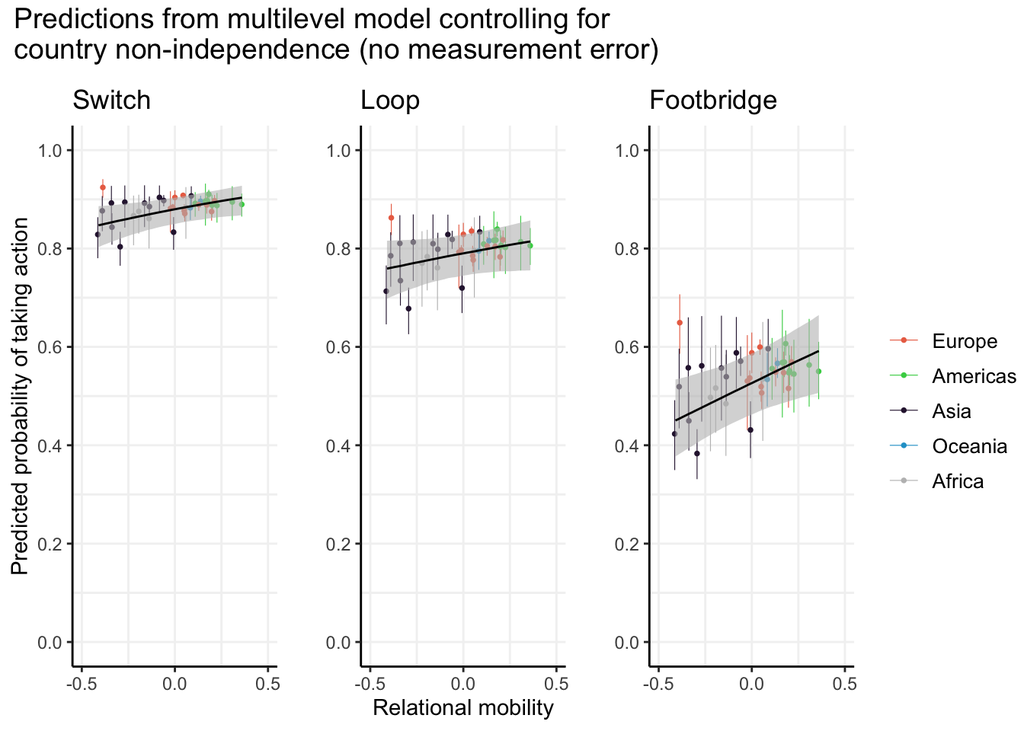

Calculate slopes for each scenario (on the log-odds scale).

```r
# slope of RML in Switch scenario
slope_switch <- post2$b_RML + post2$`b_ScenarioSwitch:RML`
quantile(slope_switch, qs) %>% round(2)
```

```
##  2.5%   50% 97.5%
##  0.09  0.67  1.20
```

```r
# slope of RML in Loop scenario
slope_loop <- post2$b_RML + post2$`b_ScenarioLoop:RML`
quantile(slope_loop, qs) %>% round(2)
```

```
##  2.5%   50% 97.5%
## -0.17  0.42  0.95
```

```r
# slope of RML in Footbridge scenario
slope_foot <- post2$b_RML
quantile(slope_foot, qs) %>% round(2)
```

```
##  2.5%   50% 97.5%
##  0.17  0.73  1.24
```

The slope remains reliably positive for Switch and Footbridge scenarios, but not Loop.

## 4.3. Controlling for non-independence with measurement error on RML

```r
summary(m3)
```

```
##  Family: bernoulli
##   Links: mu = logit
## Formula: Outcome ~ 0 + intercept + Scenario * me(x = RML, sdx = RML_SE, gr = country_code) + (0 + intercept | country_code) + (0 + intercept | country_code2) + (0 + intercept | UserID)
##    Data: d (Number of observations: 182780)
## Samples: 4 chains, each with iter = 4000; warmup = 2000; thin = 1;
##          total post-warmup samples = 8000
##
## Group-Level Effects:
## ~country_code (Number of levels: 38)
##               Estimate Est.Error l-95% CI u-95% CI Rhat Bulk_ESS Tail_ESS
## sd(intercept)     0.27      0.05     0.17     0.37 1.00     2517     2554
##
## ~country_code2 (Number of levels: 38)
##               Estimate Est.Error l-95% CI u-95% CI Rhat Bulk_ESS Tail_ESS
## sd(intercept)     0.11      0.06     0.01     0.24 1.00     1265     2334
##
## ~UserID (Number of levels: 56871)
##               Estimate Est.Error l-95% CI u-95% CI Rhat Bulk_ESS Tail_ESS
## sd(intercept)     1.62      0.01     1.60     1.63 1.00     6363     5913
##
## Population-Level Effects:
##                                                    Estimate Est.Error l-95% CI u-95% CI Rhat Bulk_ESS Tail_ESS
## intercept                                              0.09      0.09    -0.09     0.27 1.00     5234     5443
## ScenarioLoop                                           1.24      0.01     1.22     1.27 1.00     9791     5691
## ScenarioSwitch                                         1.92      0.01     1.89     1.94 1.00    11241     6646
## mexEQRMLsdxEQRML_SEgrEQcountry_code                    0.91      0.19     0.53     1.29 1.00     4583     5540
## mexEQRMLsdxEQRML_SEgrEQcountry_code:ScenarioLoop      -0.86      0.06    -0.99    -0.74 1.00     9736     6696
## mexEQRMLsdxEQRML_SEgrEQcountry_code:ScenarioSwitch    -0.73      0.07    -0.86    -0.61 1.00    11128     6252
##
## Samples were drawn using sampling(NUTS). For each parameter, Eff.Sample
## is a crude measure of effective sample size, and Rhat is the potential
## scale reduction factor on split chains (at convergence, Rhat = 1).
```

Plot the predictions of `m3` and compare to the original paper. Panel A refers to the original paper, and Panel B refers to our model (shaded areas denotes 95% credible intervals).

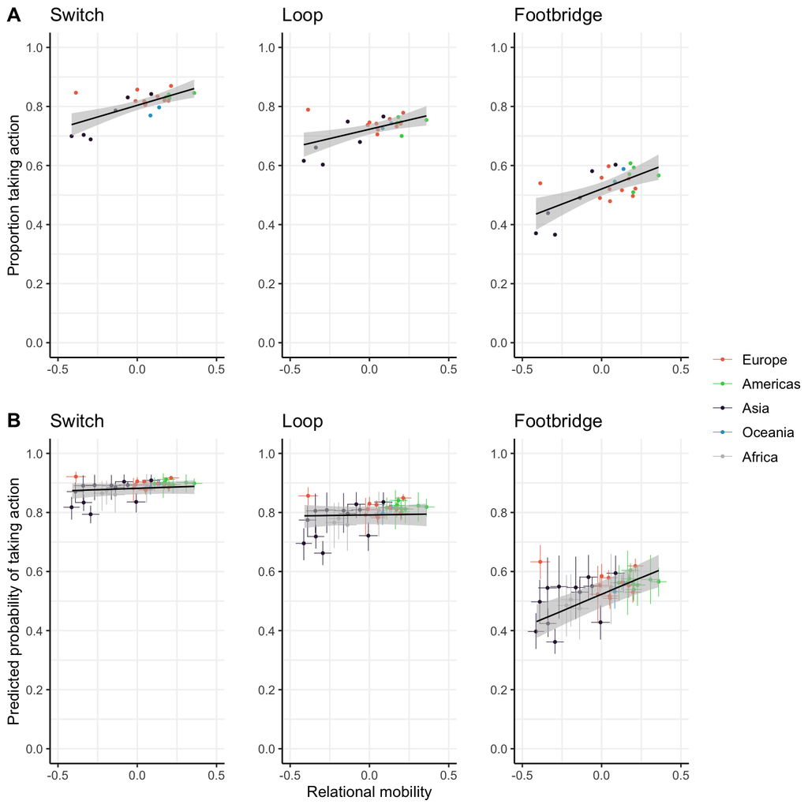

Calculate slopes for each scenario (on the log-odds scale).

```r
# slope of RML in Switch scenario
slope_switch <- post3$bsp_mexEQRMLsdxEQRML_SEgrEQcountry_code + post3$`bsp_mexEQRMLsdxEQRML_SEgrEQcountry_code:ScenarioSwitch`
quantile(slope_switch, qs) %>% round(2)
```

```
##  2.5%   50% 97.5%
## -0.21  0.18  0.57
```

```r
# slope of RML in Loop scenario
slope_loop <- post3$bsp_mexEQRMLsdxEQRML_SEgrEQcountry_code + post3$`bsp_mexEQRMLsdxEQRML_SEgrEQcountry_code:ScenarioLoop`
quantile(slope_loop, qs) %>% round(2)
```

```
##  2.5%   50% 97.5%
## -0.35  0.04  0.43
```

```r
# slope of RML in Footbridge scenario
slope_foot <- post3$bsp_mexEQRMLsdxEQRML_SEgrEQcountry_code
quantile(slope_foot, qs) %>% round(2)
```

```
##  2.5%   50% 97.5%
##  0.53  0.91  1.29
```

The slope remains reliably positive for Footbridge, but not for Switch or Loop.

## 4.4. Controlling for non-independence with measurement error on RML (plus GDP control)

```r
summary(m4)
```

```
##  Family: bernoulli
##   Links: mu = logit
## Formula: Outcome ~ 0 + intercept + Scenario * me(x = RML, sdx = RML_SE, gr = country_code) + Scenario:GDP_log10 + (0 + intercept | country_code) + (0 + intercept | country_code2) + (0 + intercept | UserID)
##    Data: d (Number of observations: 179545)
## Samples: 4 chains, each with iter = 4000; warmup = 2000; thin = 1;
##          total post-warmup samples = 8000
##
## Group-Level Effects:
## ~country_code (Number of levels: 33)
##               Estimate Est.Error l-95% CI u-95% CI Rhat Bulk_ESS Tail_ESS
## sd(intercept)     0.24      0.05     0.13     0.34 1.00     1782     1434
##
## ~country_code2 (Number of levels: 33)
##               Estimate Est.Error l-95% CI u-95% CI Rhat Bulk_ESS Tail_ESS
## sd(intercept)     0.11      0.06     0.01     0.23 1.00     1191     1941
##
## ~UserID (Number of levels: 55827)
##               Estimate Est.Error l-95% CI u-95% CI Rhat Bulk_ESS Tail_ESS
## sd(intercept)     1.61      0.01     1.60     1.63 1.00     6518     6498
##
## Population-Level Effects:
##                                                    Estimate Est.Error l-95% CI u-95% CI Rhat Bulk_ESS Tail_ESS
## intercept                                              0.12      0.09    -0.06     0.30 1.00     4247     4564
## ScenarioLoop                                           1.25      0.01     1.22     1.28 1.00     8181     6655
## ScenarioSwitch                                         1.92      0.01     1.90     1.95 1.00     7671     6028
## ScenarioFootbridge:GDP_log10                          -0.14      0.19    -0.51     0.22 1.00     2689     3530
## ScenarioLoop:GDP_log10                                 0.28      0.18    -0.08     0.65 1.00     2579     3601
## ScenarioSwitch:GDP_log10                              -0.32      0.19    -0.69     0.05 1.00     2594     3640
## mexEQRMLsdxEQRML_SEgrEQcountry_code                    0.88      0.19     0.50     1.26 1.00     4202     4747
## mexEQRMLsdxEQRML_SEgrEQcountry_code:ScenarioLoop      -0.82      0.06    -0.95    -0.70 1.00     8116     6579
## mexEQRMLsdxEQRML_SEgrEQcountry_code:ScenarioSwitch    -0.75      0.07    -0.88    -0.63 1.00     7227     5515
##
## Samples were drawn using sampling(NUTS). For each parameter, Eff.Sample
## is a crude measure of effective sample size, and Rhat is the potential
## scale reduction factor on split chains (at convergence, Rhat = 1).
```

Plot the predictions of `m4`.

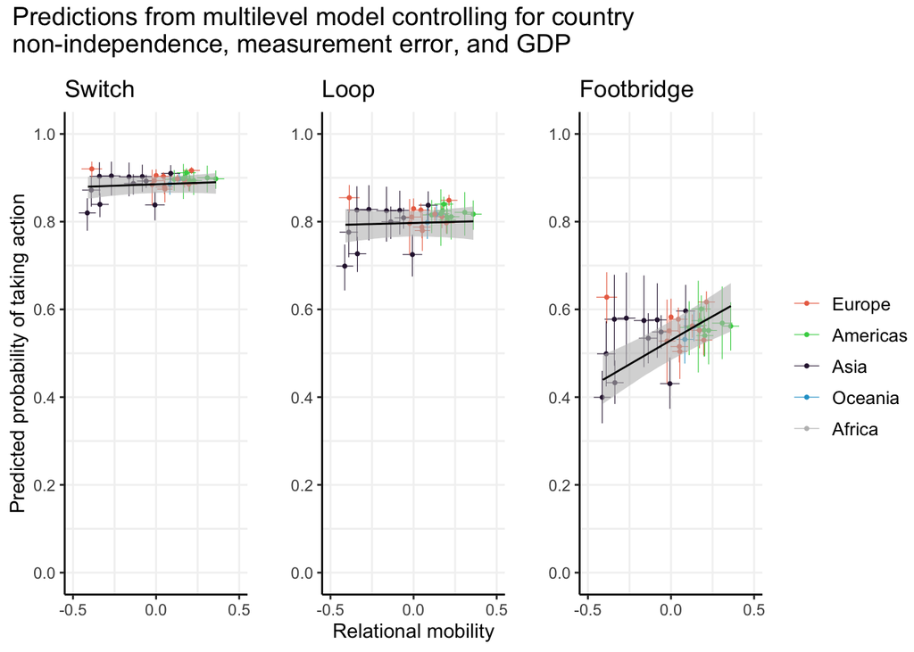

Calculate slopes for each scenario (on the log-odds scale) when controlling for GDP.

```r
# slope of RML in Switch scenario
slope_switch <- post4$bsp_mexEQRMLsdxEQRML_SEgrEQcountry_code + post4$`bsp_mexEQRMLsdxEQRML_SEgrEQcountry_code:ScenarioSwitch`
quantile(slope_switch, qs) %>% round(2)
```

```
##  2.5%   50% 97.5%
## -0.27  0.13  0.52
```

```r
# slope of RML in Loop scenario
slope_loop <- post4$bsp_mexEQRMLsdxEQRML_SEgrEQcountry_code + post4$`bsp_mexEQRMLsdxEQRML_SEgrEQcountry_code:ScenarioLoop`
quantile(slope_loop, qs) %>% round(2)
```

```
##  2.5%   50% 97.5%
## -0.34  0.06  0.44
```

```r
# slope of RML in Footbridge scenario
slope_foot <- post4$bsp_mexEQRMLsdxEQRML_SEgrEQcountry_code
quantile(slope_foot, qs) %>% round(2)
```

```
##  2.5%   50% 97.5%
##  0.50  0.89  1.26
```

The slope remains reliably positive for Footbridge, but not for Switch or Loop.

## 4.5. Controlling for non-independence with measurement error on RML (plus Individualism control)

```r
summary(m5)
```

```
##  Family: bernoulli
##   Links: mu = logit
## Formula: Outcome ~ 0 + intercept + Scenario * me(x = RML, sdx = RML_SE, gr = country_code) + Scenario:Individualism + (0 + intercept | country_code) + (0 + intercept | country_code2) + (0 + intercept | UserID)
##    Data: d (Number of observations: 178799)
## Samples: 4 chains, each with iter = 4000; warmup = 2000; thin = 1;
##          total post-warmup samples = 8000
##
## Group-Level Effects:
## ~country_code (Number of levels: 28)
##               Estimate Est.Error l-95% CI u-95% CI Rhat Bulk_ESS Tail_ESS
## sd(intercept)     0.26      0.05     0.16     0.37 1.00     2973     3210
##
## ~country_code2 (Number of levels: 28)
##               Estimate Est.Error l-95% CI u-95% CI Rhat Bulk_ESS Tail_ESS
## sd(intercept)     0.11      0.06     0.01     0.23 1.00     1377     2245
##
## ~UserID (Number of levels: 55602)
##               Estimate Est.Error l-95% CI u-95% CI Rhat Bulk_ESS Tail_ESS
## sd(intercept)     1.62      0.01     1.60     1.63 1.00     5793     6199
##
## Population-Level Effects:
##                                                    Estimate Est.Error l-95% CI u-95% CI Rhat Bulk_ESS Tail_ESS
## intercept                                              0.16      0.10    -0.03     0.35 1.00     4587     5386
## ScenarioLoop                                           1.25      0.01     1.22     1.28 1.00     9955     6324
## ScenarioSwitch                                         1.91      0.01     1.88     1.94 1.00     9109     6087
## ScenarioFootbridge:Individualism                       0.00      0.00    -0.00     0.01 1.00     2264     3998
## ScenarioLoop:Individualism                             0.01      0.00     0.00     0.01 1.00     2221     3786
## ScenarioSwitch:Individualism                           0.00      0.00    -0.00     0.01 1.00     2213     3775
## mexEQRMLsdxEQRML_SEgrEQcountry_code                    0.85      0.20     0.46     1.23 1.00     4380     5559
## mexEQRMLsdxEQRML_SEgrEQcountry_code:ScenarioLoop      -0.92      0.06    -1.04    -0.80 1.00     9752     6155
## mexEQRMLsdxEQRML_SEgrEQcountry_code:ScenarioSwitch    -0.67      0.07    -0.81    -0.54 1.00     8881     6041
##
## Samples were drawn using sampling(NUTS). For each parameter, Eff.Sample
## is a crude measure of effective sample size, and Rhat is the potential
## scale reduction factor on split chains (at convergence, Rhat = 1).
```

Plot the predictions of `m5`.

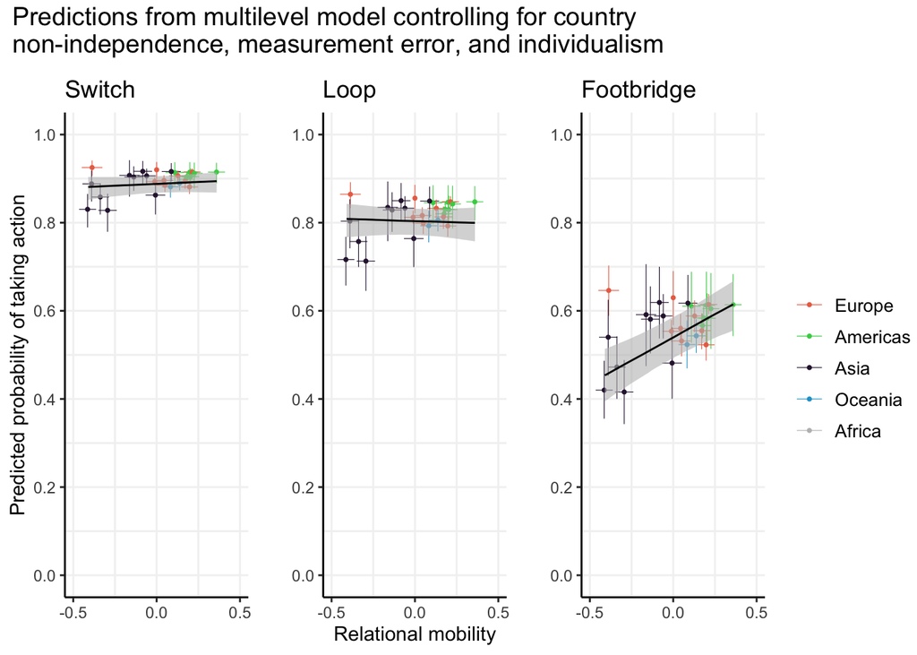

Calculate slopes for each scenario (on the log-odds scale) when controlling for individualism.

```r
# slope of RML in Switch scenario
slope_switch <- post5$bsp_mexEQRMLsdxEQRML_SEgrEQcountry_code + post5$`bsp_mexEQRMLsdxEQRML_SEgrEQcountry_code:ScenarioSwitch`
quantile(slope_switch, qs) %>% round(2)
```

```
##  2.5%   50% 97.5%
## -0.22  0.17  0.58
```

```r
# slope of RML in Loop scenario
slope_loop <- post5$bsp_mexEQRMLsdxEQRML_SEgrEQcountry_code + post5$`bsp_mexEQRMLsdxEQRML_SEgrEQcountry_code:ScenarioLoop`
quantile(slope_loop, qs) %>% round(2)
```

```
##  2.5%   50% 97.5%
## -0.47 -0.07  0.32
```

```r
# slope of RML in Footbridge scenario
slope_foot <- post5$bsp_mexEQRMLsdxEQRML_SEgrEQcountry_code
quantile(slope_foot, qs) %>% round(2)
```

```
##  2.5%   50% 97.5%
##  0.46  0.85  1.23
```

The slope remains reliably positive for Footbridge, but not for Switch or Loop.

## 4.6. Controlling for non-independence with measurement error on RML (plus Religiosity control)

```r
summary(m6)
```

```
##  Family: bernoulli
##   Links: mu = logit
## Formula: Outcome ~ 0 + intercept + Scenario * me(x = RML, sdx = RML_SE, gr = country_code) + Scenario:Religion_is_very_important + (0 + intercept | country_code) + (0 + intercept | country_code2) + (0 + intercept | UserID)
##    Data: d (Number of observations: 180428)
## Samples: 4 chains, each with iter = 4000; warmup = 2000; thin = 1;
##          total post-warmup samples = 8000
##
## Group-Level Effects:
## ~country_code (Number of levels: 32)
##               Estimate Est.Error l-95% CI u-95% CI Rhat Bulk_ESS Tail_ESS
## sd(intercept)     0.25      0.05     0.16     0.35 1.00     2303     2070
##
## ~country_code2 (Number of levels: 32)
##               Estimate Est.Error l-95% CI u-95% CI Rhat Bulk_ESS Tail_ESS
## sd(intercept)     0.10      0.06     0.01     0.23 1.00     1325     2291
##
## ~UserID (Number of levels: 56124)
##               Estimate Est.Error l-95% CI u-95% CI Rhat Bulk_ESS Tail_ESS
## sd(intercept)     1.62      0.01     1.61     1.64 1.00     6287     6492
##
## Population-Level Effects:
##                                                    Estimate Est.Error l-95% CI u-95% CI Rhat Bulk_ESS Tail_ESS
## intercept                                              0.10      0.09    -0.08     0.28 1.00     5539     5812
## ScenarioLoop                                           1.24      0.01     1.21     1.26 1.00    11200     6543
## ScenarioSwitch                                         1.91      0.01     1.88     1.94 1.00    10217     6436
## ScenarioFootbridge:Religion_is_very_important          0.01      0.00     0.00     0.01 1.00     3331     4848
## ScenarioLoop:Religion_is_very_important               -0.00      0.00    -0.00     0.00 1.00     3409     4143
## ScenarioSwitch:Religion_is_very_important              0.00      0.00    -0.00     0.01 1.00     3275     4348
## mexEQRMLsdxEQRML_SEgrEQcountry_code                    0.89      0.20     0.49     1.29 1.00     5680     5320
## mexEQRMLsdxEQRML_SEgrEQcountry_code:ScenarioLoop      -0.67      0.08    -0.82    -0.52 1.00    10245     5578
## mexEQRMLsdxEQRML_SEgrEQcountry_code:ScenarioSwitch    -0.55      0.09    -0.72    -0.37 1.00     7968     5821
##
## Samples were drawn using sampling(NUTS). For each parameter, Eff.Sample
## is a crude measure of effective sample size, and Rhat is the potential
## scale reduction factor on split chains (at convergence, Rhat = 1).
```

Plot the predictions of `m6`.

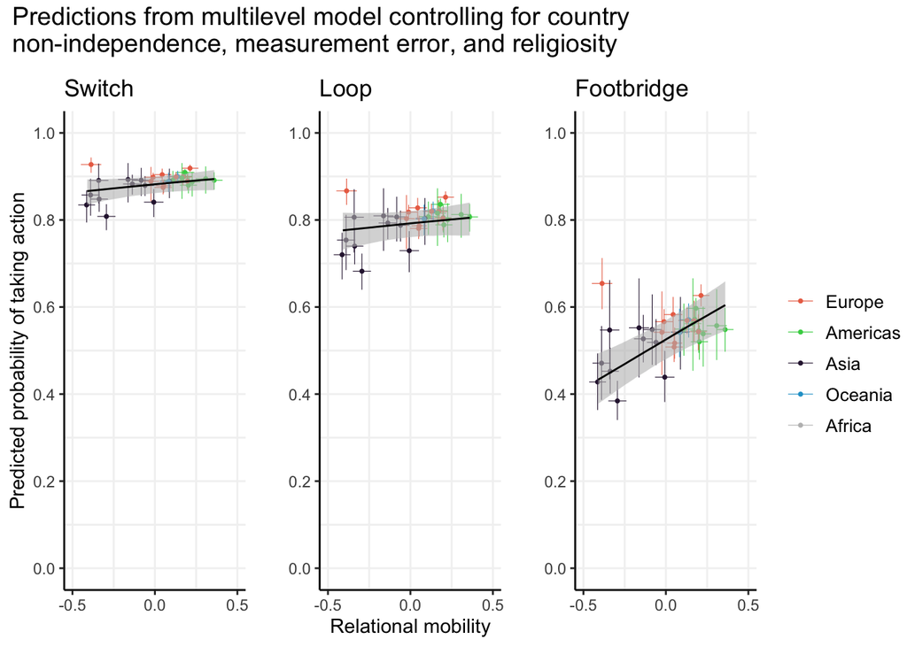

Calculate slopes for each scenario (on the log-odds scale) when controlling for religiosity.

```r
# slope of RML in Switch scenario
slope_switch <- post6$bsp_mexEQRMLsdxEQRML_SEgrEQcountry_code + post6$`bsp_mexEQRMLsdxEQRML_SEgrEQcountry_code:ScenarioSwitch`
quantile(slope_switch, qs) %>% round(2)
```

```
##  2.5%   50% 97.5%
## -0.09  0.34  0.78
```

```r
# slope of RML in Loop scenario
slope_loop <- post6$bsp_mexEQRMLsdxEQRML_SEgrEQcountry_code + post6$`bsp_mexEQRMLsdxEQRML_SEgrEQcountry_code:ScenarioLoop`
quantile(slope_loop, qs) %>% round(2)
```

```
##  2.5%   50% 97.5%
## -0.21  0.22  0.65
```

```r
# slope of RML in Footbridge scenario
slope_foot <- post6$bsp_mexEQRMLsdxEQRML_SEgrEQcountry_code
quantile(slope_foot, qs) %>% round(2)
```

```
##  2.5%   50% 97.5%
##  0.49  0.89  1.29
```

The slope remains reliably positive for Footbridge, but not for Switch or Loop.

## 4.7. Controlling for non-independence without measurement error on RML (Asian subset)

```r
summary(m7)
```

```
##  Family: bernoulli
##   Links: mu = logit
## Formula: Outcome ~ 0 + intercept + Scenario * RML + (0 + intercept | country_code) + (0 + intercept | country_code2) + (0 + intercept | UserID)
##    Data: d_Asia (Number of observations: 14957)
## Samples: 4 chains, each with iter = 4000; warmup = 2000; thin = 1;
##          total post-warmup samples = 8000
##
## Group-Level Effects:
## ~country_code (Number of levels: 12)
##               Estimate Est.Error l-95% CI u-95% CI Rhat Bulk_ESS Tail_ESS
## sd(intercept)     0.36      0.22     0.02     0.82 1.00     1847     2797
##
## ~country_code2 (Number of levels: 12)
##               Estimate Est.Error l-95% CI u-95% CI Rhat Bulk_ESS Tail_ESS
## sd(intercept)     0.38      0.21     0.03     0.83 1.00     1823     2652
##
## ~UserID (Number of levels: 4705)
##               Estimate Est.Error l-95% CI u-95% CI Rhat Bulk_ESS Tail_ESS
## sd(intercept)     1.82      0.05     1.72     1.93 1.00     2269     3665
##
## Population-Level Effects:
##                    Estimate Est.Error l-95% CI u-95% CI Rhat Bulk_ESS Tail_ESS
## intercept              0.05      0.26    -0.47     0.56 1.00     5921     5439
## ScenarioLoop           1.01      0.07     0.87     1.15 1.00     6927     6207
## ScenarioSwitch         1.85      0.08     1.70     2.01 1.00     6162     5484
## RML                    0.42      0.47    -0.53     1.34 1.00     7980     5744
## ScenarioLoop:RML      -0.99      0.27    -1.52    -0.46 1.00     7929     6967
## ScenarioSwitch:RML    -0.31      0.29    -0.87     0.26 1.00     8027     6194
##
## Samples were drawn using sampling(NUTS). For each parameter, Eff.Sample
## is a crude measure of effective sample size, and Rhat is the potential
## scale reduction factor on split chains (at convergence, Rhat = 1).
```

Plot the predictions of `m7`.

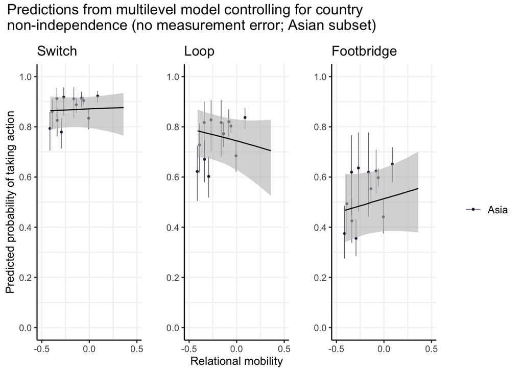

Calculate slopes for each scenario (on the log-odds scale) for the subset of Asian countries.

```r
# slope of RML in Switch scenario
slope_switch <- post7$b_RML + post7$`b_ScenarioSwitch:RML`
quantile(slope_switch, qs) %>% round(2)
```

```
##  2.5%   50% 97.5%
## -0.97  0.11  1.15
```

```r
# slope of RML in Loop scenario
slope_loop <- post7$b_RML + post7$`b_ScenarioLoop:RML`
quantile(slope_loop, qs) %>% round(2)
```

```
##  2.5%   50% 97.5%
## -1.65 -0.57  0.46
```

```r
# slope of RML in Footbridge scenario
slope_foot <- post7$b_RML
quantile(slope_foot, qs) %>% round(2)
```

```
##  2.5%   50% 97.5%
## -0.53  0.43  1.34
```

The slopes cross zero for every scenario.

## 4.8. Controlling for non-independence with measurement error on RML (Asian subset)

```r
summary(m8)
```

```
##  Family: bernoulli
##   Links: mu = logit
## Formula: Outcome ~ 0 + intercept + Scenario * me(x = RML, sdx = RML_SE, gr = country_code) + (0 + intercept | country_code) + (0 + intercept | country_code2) + (0 + intercept | UserID)
##    Data: d_Asia (Number of observations: 14957)
## Samples: 4 chains, each with iter = 4000; warmup = 2000; thin = 1;
##          total post-warmup samples = 8000
##
## Group-Level Effects:
## ~country_code (Number of levels: 12)
##               Estimate Est.Error l-95% CI u-95% CI Rhat Bulk_ESS Tail_ESS
## sd(intercept)     0.31      0.15     0.04     0.63 1.00     2194     2379
##
## ~country_code2 (Number of levels: 12)
##               Estimate Est.Error l-95% CI u-95% CI Rhat Bulk_ESS Tail_ESS
## sd(intercept)     0.36      0.15     0.06     0.66 1.00     1745     1242
##
## ~UserID (Number of levels: 4705)
##               Estimate Est.Error l-95% CI u-95% CI Rhat Bulk_ESS Tail_ESS
## sd(intercept)     1.83      0.04     1.76     1.90 1.00     4067     5042
##
## Population-Level Effects:
##                                                    Estimate Est.Error l-95% CI u-95% CI Rhat Bulk_ESS Tail_ESS
## intercept                                              0.08      0.18    -0.28     0.44 1.00     5380     5554
## ScenarioLoop                                           1.00      0.05     0.91     1.09 1.00     7947     6515
## ScenarioSwitch                                         1.89      0.05     1.79     1.99 1.00     7637     6323
## mexEQRMLsdxEQRML_SEgrEQcountry_code                    0.80      0.43    -0.06     1.63 1.00     6818     6390
## mexEQRMLsdxEQRML_SEgrEQcountry_code:ScenarioLoop      -1.34      0.19    -1.72    -0.97 1.00     8147     6376
## mexEQRMLsdxEQRML_SEgrEQcountry_code:ScenarioSwitch    -0.30      0.20    -0.69     0.10 1.00     7645     5851
##
## Samples were drawn using sampling(NUTS). For each parameter, Eff.Sample
## is a crude measure of effective sample size, and Rhat is the potential
## scale reduction factor on split chains (at convergence, Rhat = 1).
```

Plot the predictions of `m8`.

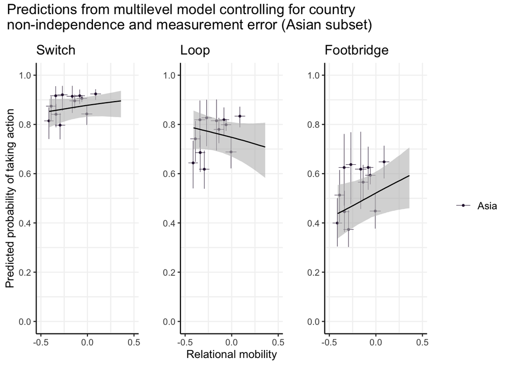

Calculate slopes for each scenario (on the log-odds scale) for the subset of Asian countries.

```r
# slope of RML in Switch scenario
slope_switch <- post8$bsp_mexEQRMLsdxEQRML_SEgrEQcountry_code + post8$`bsp_mexEQRMLsdxEQRML_SEgrEQcountry_code:ScenarioSwitch`
quantile(slope_switch, qs) %>% round(2)
```

```
##  2.5%   50% 97.5%
## -0.44  0.51  1.40
```

```r
# slope of RML in Loop scenario
slope_loop <- post8$bsp_mexEQRMLsdxEQRML_SEgrEQcountry_code + post8$`bsp_mexEQRMLsdxEQRML_SEgrEQcountry_code:ScenarioLoop`
quantile(slope_loop, qs) %>% round(2)
```

```
##  2.5%   50% 97.5%
## -1.49 -0.54  0.37
```

```r
# slope of RML in Footbridge scenario
slope_foot <- post8$bsp_mexEQRMLsdxEQRML_SEgrEQcountry_code
quantile(slope_foot, qs) %>% round(2)
```

```
##  2.5%   50% 97.5%
## -0.06  0.80  1.63
```

The slopes cross zero for every scenario.

# References

Awad, Edmond, Sohan Dsouza, Azim Shariff, Iyad Rahwan, and Jean-François Bonnefon. 2020. “Universals and variations in moral decisions made in 42 countries by 70,000 participants.” *Proceedings of the National Academy of Sciences*, January, 201911517. https://doi.org/10.1073/pnas.1911517117.

Brownrigg, M. R. 2018. “maps: Draw Geographical Maps.” https://cran.r-project.org/package=maps.

Bürkner, Paul-Christian. 2017. “brms: An R package for Bayesian multilevel models using Stan.” *Journal of Statistical Software* 80 (1): 1–28. https://doi.org/10.18637/jss.v080.i01.

Eberhard, D. M., G. F. Simons, and C. D. Fennig, eds. 2018. *Ethnologue: Languages of the World. Twenty-first edition.* Dallas, Texas: SIL International. http://www.ethnologue.com.

Eff, EA. 2008. “Weight Matrices for Cultural Proximity: Deriving Weights from a Language Phylogeny.” *Structure and Dynamics*. http://escholarship.org/uc/item/13v3x5xw.pdf.

Hammarstrom, Harald, Robert Forkel, and Martin Haspelmath. 2018. “Glottolog 3.0.” Jena: Max Planck Institute for the Science of Human History. https://glottolog.org/ accessed 2019-01-16.

Hijmans, Robert J. 2017. “geosphere: Spherical Trigonometry.” https://cran.r-project.org/package=geosphere.

McElreath, Richard. 2016. *Statistical Rethinking: A Bayesian Course with Examples in R and Stan*. CRC Press.

Thomson, Robert, Masaki Yuki, Thomas Talhelm, Joanna Schug, Mie Kito, Arin H. Ayanian, Julia C. Becker, et al. 2018. “Relational mobility predicts social behaviors in 39 countries and is tied to historical farming and threat.” *Proceedings of the National Academy of Sciences of the United States of America* 115 (29): 7521–6. https://doi.org/10.1073/pnas.1713191115.